# FastRTutorial

# Lesson 14: Introduction to Base R Graphics

```r
load(url('https://github.com/matloff/fasteR/blob/master/data/prgeng.RData?raw=true'))
head(prgeng)
```

```
##        age educ occ sex wageinc wkswrkd
## 1 50.30082   13 102   2   75000      52
## 2 41.10139    9 101   1   12300      20
## 3 24.67374    9 102   2   15400      52
## 4 50.19951   11 100   1       0      52
## 5 51.18112   11 100   2     160       1
## 6 57.70413   11 100   1       0       0
```

Scatter plot of wage vs. age

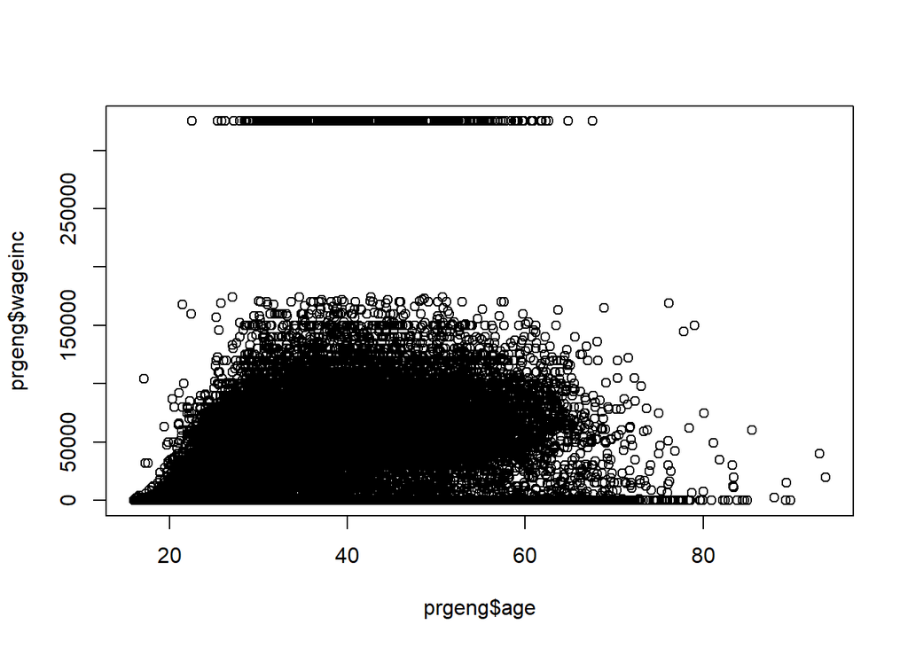

```r
plot(prgeng$age,prgeng$wageinc)
```

Plotting Sample:

```r
#indxs <- sample(1:nrow(prgeng),2500)
#prgeng2500 <- prgeng[indxs,]
prgeng2500 <- prgeng[sample(1:nrow(prgeng),2500),]
pe2500 <- prgeng2500
```

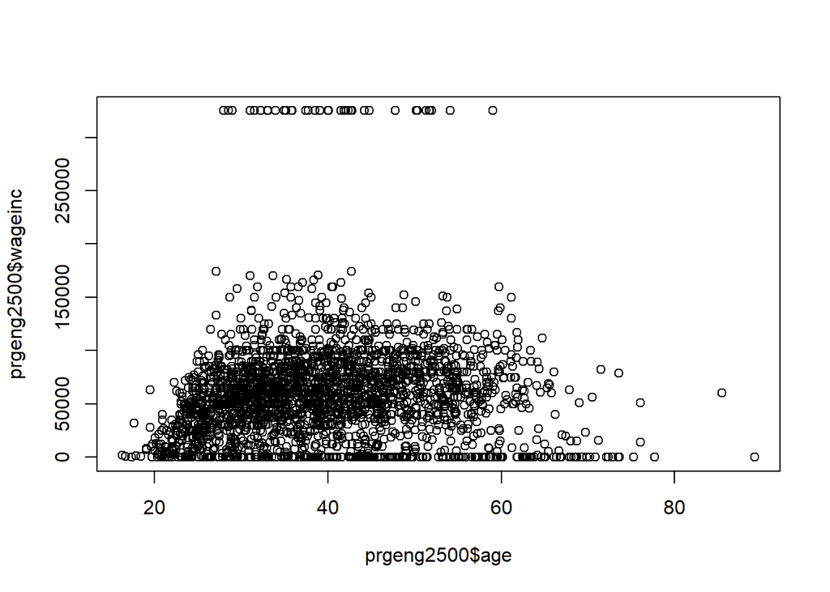

```r
plot(prgeng2500$age,prgeng2500$wageinc)
```

Color Code by Gender

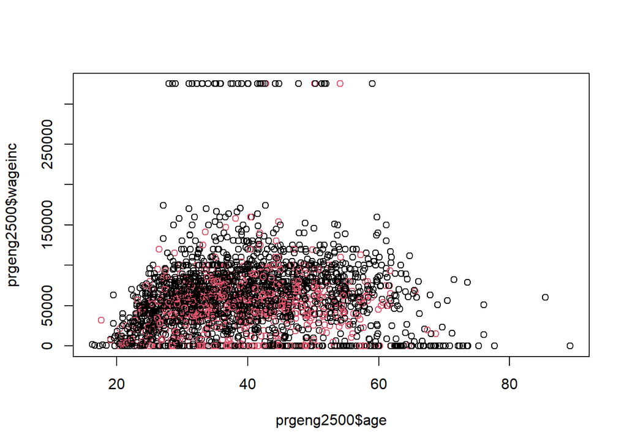

```r
plot(prgeng2500$age,prgeng2500$wageinc,col=prgeng2500$sex)
```

Improve axis labels and point size:

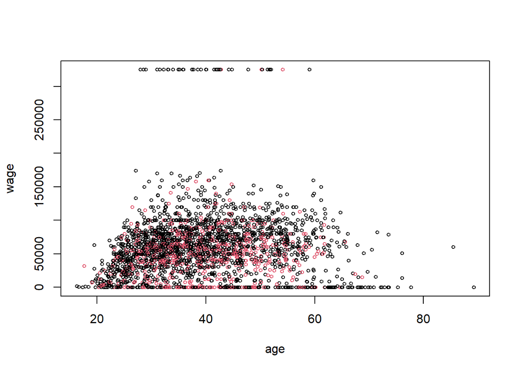

```r
plot(pe2500$age, pe2500$wageinc,  # plot age vs. wage
     col=as.factor(pe2500$sex),   # color by sex column
     xlab='age',    # x axis label
     ylab='wage',   # y axis label
     cex=0.6)       # draw at 60% default size
```

# Lesson 15: More on Base Graphics

### Split data by gender:

```r
wageByGender <- split(prgeng$wageinc,prgeng$sex)
dm <- density(wageByGender[[1]])
dw <- density(wageByGender[[2]])
```

**wageByGender[[1]]** will now be the vector of men’s wages, and similarly **wageByGender[[2]]** will have the women’s wages.

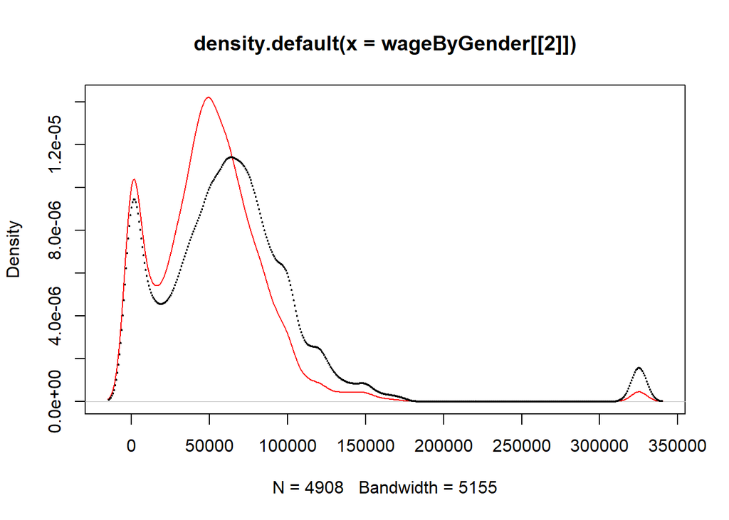

```r
plot(dw,col='red')
points(dm,cex=0.2)
```

Call plot and then points: calling **plot** twice would destroy the first plot; we merely want to *add points* to the existing graph. Plot women’s data first: the women’s curve is taller, so if we plotted the men first, part of the women’s curve would be cut off.

# Lesson 16: Writing Your Own Functions

Computing the mean of a vector:

```r
mean(Nile[Nile > 1200])
```

```
## [1] 1250
```

Broken down into 3 steps:

```r
gt1200Indices <- which(Nile > 1200)
nileSubsetGT1200 <- Nile[gt1200Indices]
mean(nileSubsetGT1200)
```

```
## [1] 1250
```

Steps:

1. In line 1, we find the indices in **Nile** for the elements larger than 1200.
2. In line 2, we extract the subset of **Nile** consisting of those elements.
3. In line 3, we compute the desired mean.

### Writing a Function:

```r
mgd <- function(x,d) return(mean(x[x > d]))
```

The return is not needed here, since in any function, **R will return the last value computed,** in this case the requested mean.

```r
mgd <- function(x,d) mean(x[x > d])
```

**Formal Arguments:**

- x: vector
- d: value with which to subset vector x with x[x > d]

### Saving an R Object:

```r
save(mgd,file='mean_greater_than_d')
```

### Accessing an R Object:

```r
load('mean_greater_than_d')
```

### Writing a Range Function:

```r
rng <- function(y) max(y) - min(y)
rng(Nile)
```

```
## [1] 914
```

# Lesson 17: For Loops

### For Loop Example

Manually fill in 0s as NA in glucose column

```r
pima$glucose[pima$glucose == 0] <- NA
```

Find and print all 0 values in all columns of pima dataset

```r
for (i in 1:9) print(sum(pima[,i] == 0))
```

```
## [1] 111
## [1] NA
## [1] 35
## [1] 227
## [1] 374
## [1] 11
## [1] 0
## [1] 0
## [1] 500
```

```r
for (colNumber in 1:9) print(sum(pima[,colNumber] == 0))
```

```
## [1] 111
## [1] NA
## [1] 35
## [1] 227
## [1] 374
## [1] 11
## [1] 0
## [1] 0
## [1] 500
```

```r
colnames(pima)
```

```
## [1] "pregnant"  "glucose"   "diastolic" "triceps"   "insulin"   "bmi"
## [7] "diabetes"  "age"       "test"
```

Use for loop to fill in 0s as NA in appropriate columns

```r
for (i in 3:6) pima[pima[,i] == 0,i] <- NA
```

```r
for (i in 2:6) {
   zeroIndices <- which(pima[,i] == 0)
   pima[zeroIndices,i] <- NA
}
```

# Break Construct

Say we are adding cubes of numbers 1,2,3,..., and for some reason want to determine which sum is the first to exceed **s**. If our accumulated total meets our goal, we leave the loop early.

```r
f <- function(n,s) {
   tot <- 0
   for (i in 1:n) {
      tot <- tot + i^3
      if (tot > s) {
         print(i)
         break
      }
      if (i == n) print('failed')
   }
}
```

# Lesson 18: Functions with Blocks

General function to replace 0s with NAs:

```r
zerosToNAs <- function(d,cols){
   for (j in cols) {
      NArows <- which(d[,j] == 0)
      d[NArows,j] <- NA
   }
   d
}
```

```r
head(zerosToNAs(pima,2:6))
```

```
##   pregnant glucose diastolic triceps insulin  bmi diabetes age test
## 1        6     148        72      35      NA 33.6    0.627  50    1
## 2        1      85        66      29      NA 26.6    0.351  31    0
## 3        8     183        64      NA      NA 23.3    0.672  32    1
## 4        1      89        66      23      94 28.1    0.167  21    0
## 5        0     137        40      35     168 43.1    2.288  33    1
## 6        5     116        74      NA      NA 25.6    0.201  30    0
```

# Lesson 19: Text Editing and IDEs

### Text editing options:

1. If you are already using an IDE, say RStudio, you simply edit in the designated pane.
2. If you are using an external editor, say vim or emacs, just open a new file and use that workspace.
3. For those not using these, we’ll just use R’s built-in **edit** function.

### 1. RStudio Option

Define function and call

```r
f <- function(x,y){
   s <- x + y
   d <- x - y
   c(s,d)
}
```

```r
f(5,2)
```

```
## [1] 7 3
```

### 2. External Text Editor Option

If an external text editor is used, save code into file such as “a.R”, and then load file:

`source('a.R')`

Then run f as usual with R.

### **3. Edit Option**

Open a blank text editor, save text to “f”

`f <- edit()`

Opens text editor with f’s current contents, save edited text to “f”

`f <- edit(f)`

Then run f as usual with R.

# Lesson 20: If, Else, Ifelse

### “If” Example:

Label all education levels under 13 as 12

```r
pe <- prgeng
pe$educ <- as.numeric(pe$educ)
head(pe$educ,15)
```

```
##  [1] 13  9  9 11 11 11 12 11 14  9 12 13 12 13  6
```

```r
for (i in 1:nrow(pe)) {
   if (pe$educ[i] < 13) pe$educ[i] <- 12
}
head(pe$educ,15)
```

```
##  [1] 13 12 12 12 12 12 12 12 14 12 12 13 12 13 12
```

```r
pe <- prgeng
pe$educ <- as.numeric(pe$educ)
edu <- pe$educ
pe$educ <- ifelse(edu < 13,12,edu)
```

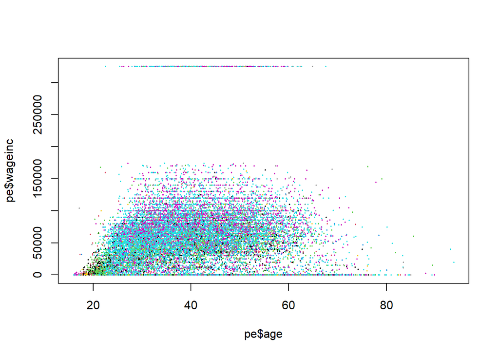

```r
plot(pe$age,pe$wageinc,col=edu, cex=0.2)
```

### “If Else” Example:

```r
if (x < 3) y <- -1 else y <- 1
```

### “Ifelse” Example:

```r
pe$educ <- ifelse(edu < 13,12,edu)
```

Re-code Nile data to a new vector “nile” with values 1, 2, 3 for the cases in which the value is:

1. less than 800
2. between 800 and 1150 inclusive
3. greater than 1150.

```r
nile <- ifelse(Nile > 1150,3,2)
nile <- ifelse(Nile < 800,1,nile)
table(nile)
```

```
## nile
##  1  2  3
## 26 62 12
```

# Lesson 21: Do Professional Athletes Keep Fit?

```r
load(url('https://github.com/matloff/fasteR/blob/master/data/mlb.RData?raw=true'))
head(mlb)
```

```
##              Name Team       Position Height Weight   Age PosCategory
## 1   Adam_Donachie  BAL        Catcher     74    180 22.99     Catcher
## 2       Paul_Bako  BAL        Catcher     74    215 34.69     Catcher
## 3 Ramon_Hernandez  BAL        Catcher     72    210 30.78     Catcher
## 4    Kevin_Millar  BAL  First_Baseman     72    210 35.43   Infielder
## 5     Chris_Gomez  BAL  First_Baseman     73    188 35.71   Infielder
## 6   Brian_Roberts  BAL Second_Baseman     69    176 29.39   Infielder
```

Explore age:

```r
age <- round(mlb$Age)
table(age)
```

```
## age
##  21  22  23  24  25  26  27  28  29  30  31  32  33  34  35  36  37  38  39  40
##   2  20  58  80 103 104 106  84  80  74  70  44  44  32  32  22  20  12   6   7
##  41  42  43  44  49
##   9   2   2   1   1
```

### Evaluate Age and Weight Relationship:

Split weight vector according to correspondingelements in age vector, and find the mean weight in each resulting group:

```r
taout <- tapply(mlb$Weight,age,mean)
names(taout) # display age groups
```

```
##  [1] "21" "22" "23" "24" "25" "26" "27" "28" "29" "30" "31" "32" "33" "34" "35"
## [16] "36" "37" "38" "39" "40" "41" "42" "43" "44" "49"
```

Plot the means against age:

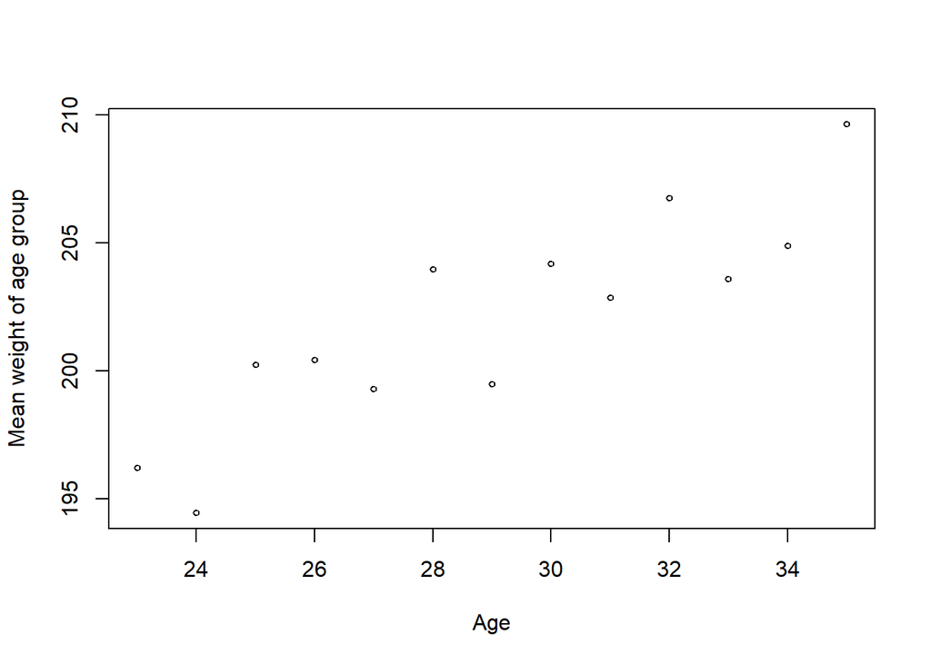

```r
plot(23:35,taout[3:15],
     xlab='Age',    # x axis label
     ylab='Mean weight of age group',   # y axis label
     cex=0.6)
```

### Evaluate Position vs. Weight Relationship

Get mean weight of each position

```r
position <- mlb$PosCategory
tpout <- tapply(mlb$Weight,position,mean)
names(tpout) # display position groups
```

```
## [1] "Catcher"    "Infielder"  "Outfielder" "Pitcher"
```

Plot mean weight for each position

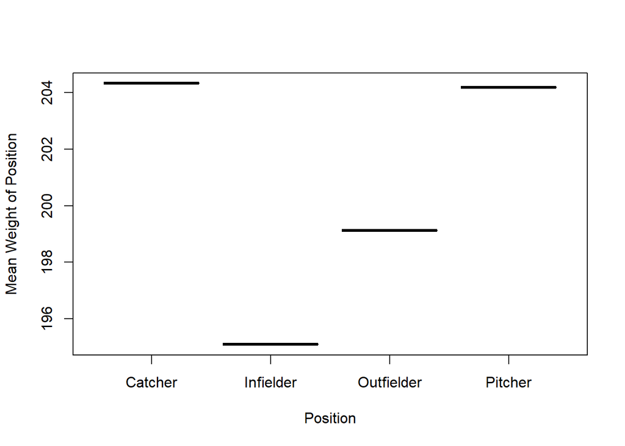

```r
names <- unique(mlb$PosCategory)
plot(names,tpout,
     xlab='Position',    # x axis label
     ylab='Mean Weight of Position',   # y axis label
     )
```

# Lesson 22: Linear Regression Analysis, I

### Generate Linear Model

```r
lm(Weight ~ Age,data=mlb)
```

```
##
## Call:
## lm(formula = Weight ~ Age, data = mlb)
##
## Coefficients:
## (Intercept)          Age
##    181.4366       0.6936
```

### Plot Linear Model

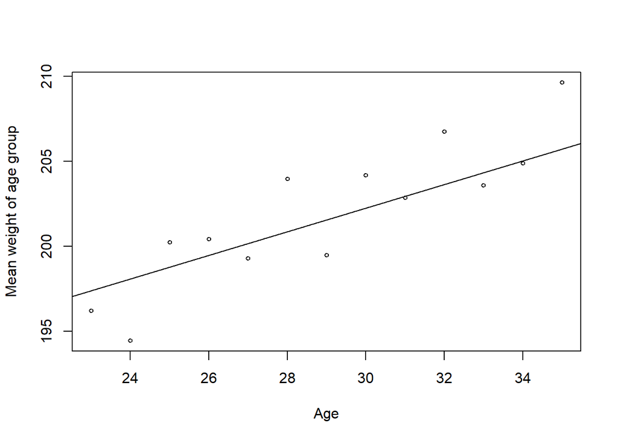

```r
plot(23:35,taout[3:15],
     xlab='Age',    # x axis label
     ylab='Mean weight of age group',   # y axis label
     cex=0.6)
abline(181.4366,0.6936)
```

# Lesson 23: S3 Classes

### Access Linear Model Class

lm creates a linear model object, which stores the coefficients

```r
lmout <- lm(Weight ~ Age,data=mlb)
class(lmout)
```

```
## [1] "lm"
```

```r
str(lmout)
```

```
## List of 12
##  $ coefficients : Named num [1:2] 181.437 0.694
##   ..- attr(*, "names")= chr [1:2] "(Intercept)" "Age"
##  $ residuals    : Named num [1:1015] -17.38 9.5 7.21 3.99 -18.21 ...
##   ..- attr(*, "names")= chr [1:1015] "1" "2" "3" "4" ...
##  $ effects      : Named num [1:1015] -6414.78 -95.29 7.59 4.04 -18.18 ...
##   ..- attr(*, "names")= chr [1:1015] "(Intercept)" "Age" "" "" ...
##  $ rank         : int 2
##  $ fitted.values: Named num [1:1015] 197 205 203 206 206 ...
##   ..- attr(*, "names")= chr [1:1015] "1" "2" "3" "4" ...
##  $ assign       : int [1:2] 0 1
##  $ qr           :List of 5
##   ..$ qr   : num [1:1015, 1:2] -31.8591 0.0314 0.0314 0.0314 0.0314 ...
##   .. ..- attr(*, "dimnames")=List of 2
##   .. .. ..$ : chr [1:1015] "1" "2" "3" "4" ...
##   .. .. ..$ : chr [1:2] "(Intercept)" "Age"
##   .. ..- attr(*, "assign")= int [1:2] 0 1
##   ..$ qraux: num [1:2] 1.03 1.04
##   ..$ pivot: int [1:2] 1 2
##   ..$ tol  : num 1e-07
##   ..$ rank : int 2
##   ..- attr(*, "class")= chr "qr"
##  $ df.residual  : int 1013
##  $ xlevels      : Named list()
##  $ call         : language lm(formula = Weight ~ Age, data = mlb)
##  $ terms        :Classes 'terms', 'formula'  language Weight ~ Age
##   .. ..- attr(*, "variables")= language list(Weight, Age)
##   .. ..- attr(*, "factors")= int [1:2, 1] 0 1
##   .. .. ..- attr(*, "dimnames")=List of 2
##   .. .. .. ..$ : chr [1:2] "Weight" "Age"
##   .. .. .. ..$ : chr "Age"
##   .. ..- attr(*, "term.labels")= chr "Age"
##   .. ..- attr(*, "order")= int 1
##   .. ..- attr(*, "intercept")= int 1
##   .. ..- attr(*, "response")= int 1
##   .. ..- attr(*, ".Environment")=<environment: R_GlobalEnv>
##   .. ..- attr(*, "predvars")= language list(Weight, Age)
##   .. ..- attr(*, "dataClasses")= Named chr [1:2] "numeric" "numeric"
##   .. .. ..- attr(*, "names")= chr [1:2] "Weight" "Age"
##  $ model        :'data.frame':   1015 obs. of  2 variables:
##   ..$ Weight: int [1:1015] 180 215 210 210 188 176 209 200 231 180 ...
##   ..$ Age   : num [1:1015] 23 34.7 30.8 35.4 35.7 ...
##   ..- attr(*, "terms")=Classes 'terms', 'formula'  language Weight ~ Age
##   .. .. ..- attr(*, "variables")= language list(Weight, Age)
##   .. .. ..- attr(*, "factors")= int [1:2, 1] 0 1
##   .. .. .. ..- attr(*, "dimnames")=List of 2
##   .. .. .. .. ..$ : chr [1:2] "Weight" "Age"
##   .. .. .. .. ..$ : chr "Age"
##   .. .. ..- attr(*, "term.labels")= chr "Age"
##   .. .. ..- attr(*, "order")= int 1
##   .. .. ..- attr(*, "intercept")= int 1
##   .. .. ..- attr(*, "response")= int 1
##   .. .. ..- attr(*, ".Environment")=<environment: R_GlobalEnv>
##   .. .. ..- attr(*, "predvars")= language list(Weight, Age)
##   .. .. ..- attr(*, "dataClasses")= Named chr [1:2] "numeric" "numeric"
##   .. .. .. ..- attr(*, "names")= chr [1:2] "Weight" "Age"
##  - attr(*, "class")= chr "lm"
```

1. Our **lmout** object here is an R list (which is typical of S3 objects). That R list here has 12 elements.
2. But it has an extra *attribute*, which is the class name, in this case **‘lm’**. (So the designers of R simply chose to name the class after the function, which is not always the case.)
3. The first of the elements of this R list is named ‘coefficients’, and it is a vector containing the slope and intercept.

Access coefficients directly from object:

```r
cfs <- lmout$coefficients
```

Two ways to plot:

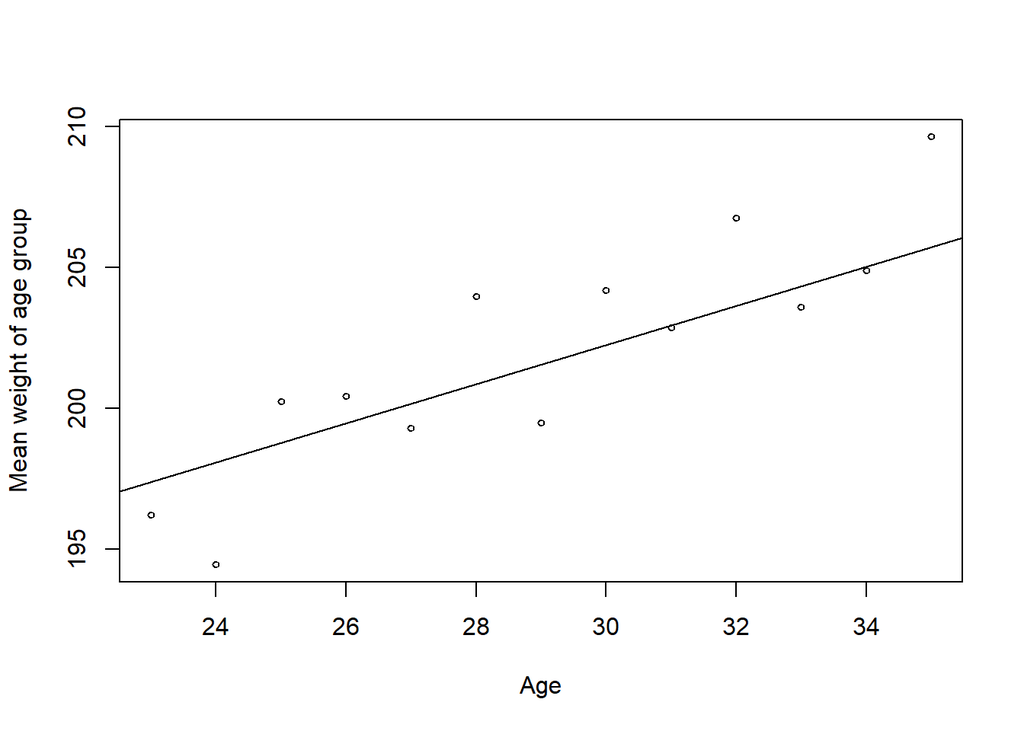

```r
plot(23:35,taout[3:15],
     xlab='Age',    # x axis label
     ylab='Mean weight of age group',   # y axis label
     cex=0.6)
abline(a = cfs[1], b = cfs[2])
abline(lmout)
```

### Account for Height and Age:

```r
lmo <- lm(Weight ~ Height + Age, data=mlb)
lmo
```

```
##
## Call:
## lm(formula = Weight ~ Height + Age, data = mlb)
##
## Coefficients:
## (Intercept)       Height          Age
##   -187.6382       4.9236       0.9115
```

This says:

```
estimated mean weight = -187.6382 + 4.9236 height + 0.9115 age
```

Conclusions:

- Players on average gain about 0.9 pounds per year.
- An extra inch of height corresponds to about 4.9 pounds of extra weight.
- Taller players are indeed heavier, as we surmised.

# Lesson 24: Baseball Player Analysis (cont’d.)

Question: do regression lines differ much among player positions?

```r
table(mlb$PosCategory)
```

```
##
##    Catcher  Infielder Outfielder    Pitcher
##         76        210        194        535
```

### Fit the regression line for each position type

Find indices of each position type:

```r
rownums <- split(1:nrow(mlb),mlb$PosCategory)
str(rownums)
```

```
## List of 4
##  $ Catcher   : int [1:76] 1 2 3 35 36 66 67 68 101 102 ...
##  $ Infielder : int [1:210] 4 5 6 7 8 9 37 38 39 40 ...
##  $ Outfielder: int [1:194] 10 11 12 13 14 15 16 43 44 45 ...
##  $ Pitcher   : int [1:535] 17 18 19 20 21 22 23 24 25 26 ...
```

Fit model to each position, store coefficients in ‘m’ data frame:

```r
posNames <- names(rownums)
m <- data.frame()
for (pos in posNames) {
   posRows <- rownums[[pos]]
   lmo <- lm(Weight ~ Age, data = mlb[posRows,])
   newrow <- lmo$coefficients
   m <- rbind(m,newrow)
}
m
```

```
##   X180.828029016113 X0.794925225995348
## 1          180.8280          0.7949252
## 2          170.2466          0.8589593
## 3          176.2884          0.7883343
## 4          185.5994          0.6543904
```

Adjust formatting:

```r
row.names(m) <- posNames
names(m) <- c('intercept','slope')
m
```

```
##            intercept     slope
## Catcher     180.8280 0.7949252
## Infielder   170.2466 0.8589593
## Outfielder  176.2884 0.7883343
## Pitcher     185.5994 0.6543904
```

# Lesson 25: R Packages, CRAN, Etc.

### Ggplot2 install

Do this any time package needs to be installed or updated

```r
#install.packages('ggplot2')
```

### Ggplot2 Load

Do this any time loading a new R session

```r
library(ggplot2)
```

# Lesson 26: A Pause, Before Going on to Advanced Topics

The remaining topics are more advanced, and lessons will be somewhat longer and more detailed that the previous ones

# Lesson 27: The ggplot2 Graphics Package